# Figure de Chladni

## Choix de la résolution pour le maillage

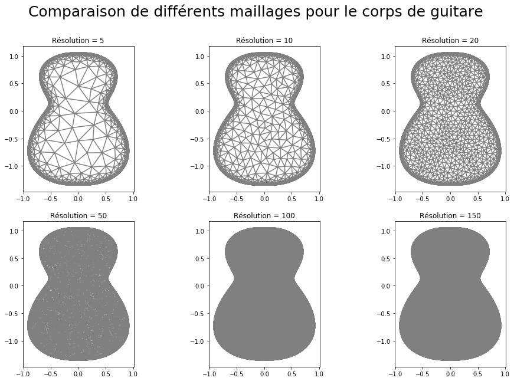

```python
# Création du mesh et affichage
list_resolutions = [5, 10, 20, 50, 100, 150]
polygonal_domain = Polygon(domain_vertices)

# Paramètres pour la taille du tracé MatPlotLib
nb_col = 3
nb_lig = 2

plt.figure(figsize=(16, 10))
for idx, resolution in enumerate(list_resolutions):
    mesh = generate_mesh(polygonal_domain, resolution)
    plt.subplot(nb_lig, nb_col, idx+1)
    plot(mesh)
    plt.title(f'Résolution = {resolution}')

plt.suptitle('Comparaison de différents maillages pour le corps de guitare', fontsize = 25)
plt.savefig(f'output/comparaison_maillage_corps_guitare.png')
```

**Analyse de la simulation :** Nous allons prendre par la suite une résolution de 150 pour avoir la meilleure précision possible.

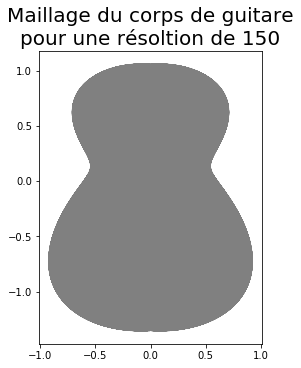

```python
# Création du mesh et affichage
resolution = 150
polygonal_domain = Polygon(domain_vertices)
mesh = generate_mesh(polygonal_domain, resolution)

plt.figure(figsize=(4,8))
plot(mesh)
plt.title(f'Maillage du corps de guitare\npour une résoltion de {resolution}', fontsize=20)
plt.savefig(f'output/maillage_corps_guitare_res={resolution}.png')
```

# Résolution de l'EDP pour un corps de guitare

On reprend le maillage précédent et on définit l'espace fonctionnel et les conditions limites comme dans le 1er cas d'étude.

```python
V = FunctionSpace(mesh, 'P', 2)

u_0 = Constant(0.1)

def boundary(x, on_boundary):
    return on_boundary

bc = DirichletBC(V, u_0, boundary)
```

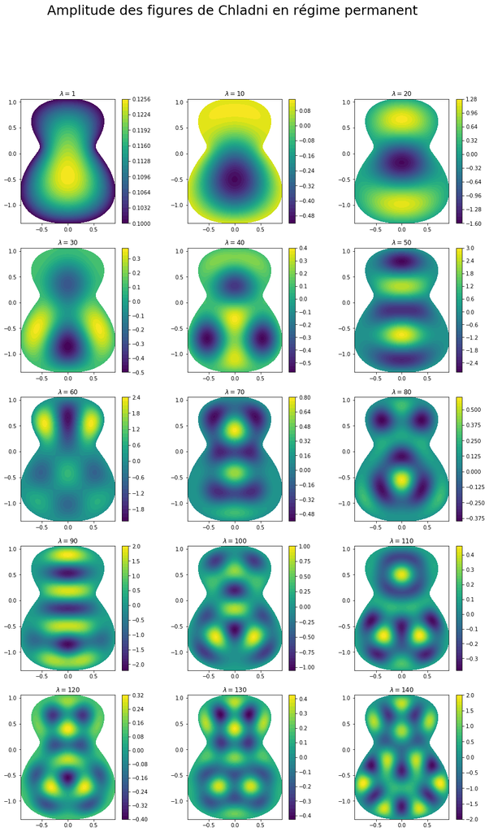

```python
list_lambda = [1] + [i for i in range(10,141,10)]
show_plot(mesh, V, bc, list_lambda, directory='Guitare - Comparaison', filename='guitar_comparaison')
```

**Description de la simulation :**  
Les modes sont symétriques par rapport à l'axe des ordonnées car notre corps de guitare l'est aussi.  
Plus qualitativement, on observe que l'aspect des modes est beaucoup plus différent que pour une plaque et semble épouser les contours du corps.  
Enfin, il semble très intéressant de pointer le rôle important que joue l'emplacement de la **rosace** (cf schéma ci-dessous) qui semble souvent coïncider avec un noeud de vibration : en pratique, on peut facilement deviner qu'elle a été placée ici pour avoir un son plus fort en sortie.

**Schéma indiquant les différentes parties d'une guitare :**

[figure not shown]

**Source :** https://www.lacartemusique.fr/blog/capodastre-guitare-classique-faites-votre-choix-n118

**Captures d'écran réaliséesavec *ParaView* et une simulation pour $\lambda = 140$ :**

[figure not shown]

# Synthèse : Résolution de l'EDP avec caractère aléatoire

Nous allons maintenant chercher à visualiser les modes propres de la guitare dans le cas où celle-ci est atteinte de défauts générés aléatoirement. Voici pour rappel une liste exhaustive des paramètres susceptibles de fluctuer aléatoirement dans notre modélisation :

- la géométrie du corps de guitare.
- le nombre de trous dans ce dernier
- la taille de ces trous
- le mode analysé.

On va reprendre la structude de la fonction `show_plot` qu'on va juste adapter pour cette partie.

```python
nb_modes = 12
```

```python
def show_plot_random(nb_modes, filename = 'synthese', get_ParaView_files=False):
    '''
    Fonction reprenant toutes les parties précédentes et affichant pour un nombre nb_modes de modes
    les figures de Chladni pour des domaines correspondant à des corps de guitare présentant des défauts
    voire des trous.

    Inputs:

    - nb_modes: nombre de modes à afficher (les valeurs de ces modes seront tirés aléatoirement)
    - filename: nom sous lequel le graphe sera enregistré, dans un dossier nommmé 'output'.
    - get_ParaView_files: à mettre à True si l'on souhaite récupérer les fichiers ParaView

    Outputs :
        None
    '''

    # Création d'un objet permettant de garder en mémoire le moment d'exécution de la fonction.
    now = datetime.now()

    # Création d'un dossier nommé selon le timestamp du moment d'exécution
    path = f'output/Synthèse/' + now.strftime("%d:%m:%Y_%H-%M-%S")

    try:
        os.mkdir(path)
    except OSError:
        print ("Creation of the directory %s failed" % path)



    # Paramètres pour la taille du tracé MatPlotLib
    nb_col = 3
    nb_lig = m.ceil(nb_modes / nb_col)


    # Tirage aléatoire des modes à étudier
    list_lambda = np.random.randint(1, 200, nb_modes).tolist()

    # On trie list_lambda pour afficher les résultat par mode croissant.
    list_lambda.sort() # side-effect


    # Préparation des dimensiosn de la figure
    plt.figure(figsize=(16, 5 * nb_lig))


    for idx, lambda0 in enumerate(list_lambda):
        # Génération du domaine
        domain_vertices = [point for point in pointGenerator(1000, is_noised=True)]

        polygonal_domain = Polygon(domain_vertices)

        domain_drilled = get_random_drilled_surface(polygonal_domain, min_nb_holes=0, max_nb_holes=3)
        mesh = generate_mesh(domain_drilled, resolution=150)


        # Définition de l'espace fonctionnel
        V = FunctionSpace(mesh, 'P', 2)


        # Définition des conditions limites
        u_0 = Constant(0.1)

        def boundary(x, on_boundary):
            return on_boundary

        bc = DirichletBC(V, u_0, boundary)


        # On se met dans le subplot correspondant
        ax = plt.subplot(nb_lig, nb_col, idx+1)


        # Définition du problème variationnel
        u = TrialFunction(V)
        v = TestFunction(V)

        f = Constant(-1.0)

        a = (dot(grad(u), grad(v)) - lambda0 * u * v) * dx
        L = f*v*dx

        eq = (dot(grad(u), grad(v)) - lambda0 * u * v) * dx

        a = lhs(eq)
        L = rhs(eq)

        w = Function(V)

        solve(a == L, w, bc)

        c = plot(w, title=f'$ \lambda = {lambda0}$')
        plt.set_xlim = ([-1.3, 1.3])
        plt.set_ylim = ([-1.3, 1.3])
        plt.axis('equal')
        plt.colorbar(c)

        if get_ParaView_files:
            # Création d'un dossier pour chaque simulation
            try:
                os.mkdir(path + f'/{idx}')
            except OSError:
                print ("Creation of the directory %s failed" % path)
            vtkfile_w = File(path + f'/{idx}/solution{idx}.pvd')
            vtkfile_w << w

    plt.suptitle('Comparaison des modes dans une guitare avec fluctuation\naléatoire des paramètres',
                 fontsize = 25)
    plt.savefig(path+'/'+filename+'.png')
    return
```

[output not shown]

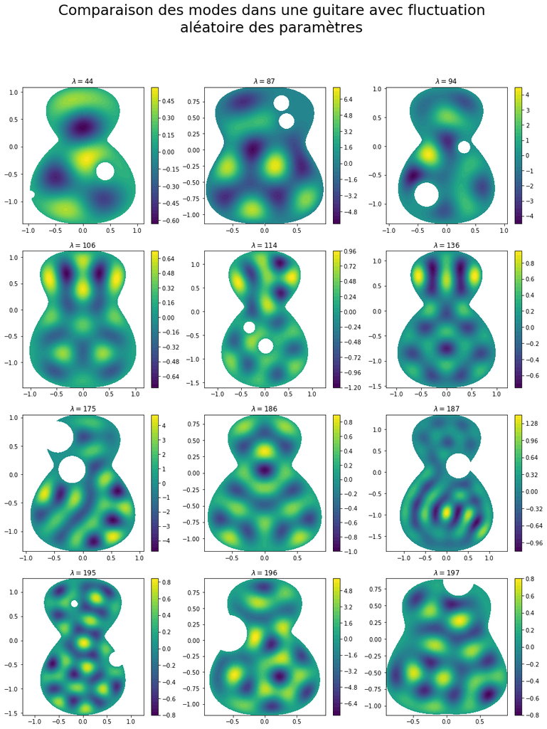

```python
show_plot_random(nb_modes, filename = 'Synthèse', get_ParaView_files=False)
```

**Captures d'écran réalisées avec *ParaView* pour une simulation obtenue avec le code `show_plot_random` :**

[figure not shown]

# Génération interactive du domaine

Pour ceux qui voudraient pouvoir ajouter manuellement les défauts, voici ci-dessous un *widget iPython* interactif pour vous permettre de faire cela.

## Fonctions outils et widgets

```python
def pointGenerator_manual(nb_points, p0, p1, p2, p3, p4, p5, p6, p7, p8, p9):
    ''' Fonction analogue à pointGenerator mais différente pour être utilisée
    avec le widget.'''
    c_initial = [5.1089, -0.008905, -0.109811, 0.000019328, 0.00270999,
         2.4455e-6, 1.2824e-5, 2.3384e-7, 2.1193e-6, 1.6911e-10]

    plt.figure(figsize=(5, 6))

    list_percents = [p0, p1, p2, p3, p4, p5, p6, p7, p8, p9]

    # On ajoute le bruit :
    c = [val * (1 + percent / 100) for val, percent in zip(c_initial, list_percents)]

    def f_bruit(x):
        num = c[0] + c[2] * x + c[4] * x**2 +c[6] * x**3 + c[8] * x**4
        den = 1 + c[1] * x + c[3] * x**2 + c[5] * x**3 + c[7] * x**4 + c[9] * x**5

        return 3 * num / (den * 25.5)

    Theta = np.linspace(-0.5 * np.pi, 0.5 *np.pi, 1000)
    ThetaDeg = 180 * Theta / np.pi
    RR = f_bruit(ThetaDeg)

    XX, YY = np.vectorize(polar_to_cartesian)(RR, Theta)
    XX2, YY2 = np.vectorize(polar_to_cartesian)(RR, np.pi - Theta)

    XX3 = np.concatenate((XX,XX2[-2:1:-1]))
    YY3 = np.concatenate((YY,YY2[-2:1:-1]))

    for i in range(np.size(XX3)):
        yield Point(XX3[i], YY3[i])
    return

def get_drilled_manual(domain, list_holes):
    for center, size in list_holes:
        domain = domain - Circle(Point(center[0], center[1]), size)
    return domain

def show_plot_manual(p0, p1, p2, p3, p4, p5, p6, p7, p8, p9,
                    isSelected0, x0, y0, size0,
                    isSelected1, x1, y1, size1,
                    isSelected2, x2, y2, size2,
                    lambda0,
                    get_ParaView_files, save_file):
    '''
    Inputs:
        - p0 à p9 sont les pourcentages à ajouter aux coefficients donant la géométrie
    du corps de guitare
        -list_holes est une liste de couples (isSelected, center, size) où isSelected
        est un booléen et center est de la forme (x, y)
    '''

    plt.ioff() # Pour ne pas afficher l'objet figure à chaque clic sur le bouton


    # Création d'un objet permettant de garder en mémoire le moment d'exécution de la fonction.
    now = datetime.now()

    # Création d'un dossier nommé selon le timestamp du moment d'exécution
    path = f'output/Interactif/' + now.strftime("%d:%m:%Y_%H-%M-%S")


    # Génération du domaine
    domain_vertices = [point for point in pointGenerator_manual(1000, p0, p1, p2, p3, p4, p5, p6, p7, p8, p9)]

    polygonal_domain = Polygon(domain_vertices)

    temp = [(isSelected0, x0, y0, size0), (isSelected1, x1, y1, size1),
                 (isSelected2, x2, y2, size2)]
    list_holes = [((elt[1], elt[2]), elt[3]) for elt in temp if elt[0]==True]

    domain_drilled = get_drilled_manual(polygonal_domain, list_holes)
    mesh = generate_mesh(domain_drilled, resolution=150)


    # Définition de l'espace fonctionnel
    V = FunctionSpace(mesh, 'P', 2)


    # Définition des conditions limites
    u_0 = Constant(0.1)

    def boundary(x, on_boundary):
        return on_boundary

    bc = DirichletBC(V, u_0, boundary)


    # Définition du problème variationnel
    u = TrialFunction(V)
    v = TestFunction(V)

    f = Constant(-1.0)

    a = (dot(grad(u), grad(v)) - lambda0 * u * v) * dx
    L = f*v*dx

    eq = (dot(grad(u), grad(v)) - lambda0 * u * v) * dx

    a = lhs(eq)
    L = rhs(eq)

    w = Function(V)

    solve(a == L, w, bc)

    c = plot(w, title=f'$ \lambda = {lambda0}$')
    plt.set_xlim = ([-1.3, 1.3])
    plt.set_ylim = ([-1.3, 1.3])
    plt.axis('equal')
    plt.colorbar(c)

    if get_ParaView_files:
        vtkfile_w = File(path + f'/solution.pvd')
        vtkfile_w << w

    plt.suptitle('Répartition des modes dans un corps de guitare')

    if save_file:
        plt.savefig(path+'/figure.png')

    plt.show()
    return
```

```python
# Pour la géométrie :
list_geometry_sliders = [widgets.IntSlider(
    value=0,
    min=-20,
    max=20,
    step=1,
    description=description,
    continuous_update=False,
    orientation='horizontal',
) for description in ['c0 ± X%', 'c1 ± X%', 'c2 ± X%', 'c3 ± X%',
                      'c4 ± X%', 'c5 ± X%', 'c6 ± X%', 'c7 ± X%',
                      'c8 ± X%', 'c9 ± X%']]

box_sliders = widgets.VBox(list_geometry_sliders)

# Pour les trous :
list_hole_widget = []

for i in range(3):
    checkbox_hole = widgets.Checkbox(
        value=False,
        description=f'Hole #{i+1}',
        disabled=False,
        indent=True
    )

    x_center_widget = widgets.BoundedFloatText(
        value=0.,
        min=-2.,
        max=2.,
        step=0.1,
        description='x_center:',
        disabled=False
    )

    y_center_widget = widgets.BoundedFloatText(
        value=0.,
        min=-2.,
        max=2.,
        step=0.1,
        description='y_center:',
        disabled=False
    )

    hole_size_widget = widgets.BoundedFloatText(
        value=0.2,
        min=0.05,
        max=0.5,
        step=0.1,
        description='Size:',
    )

    hole_container = widgets.HBox([checkbox_hole, x_center_widget, y_center_widget, hole_size_widget])
    list_hole_widget.append(hole_container)


holes_widget = widgets.VBox(list_hole_widget)

# Pour le mode :
lambda_widget = widgets.IntSlider(
    value=10,
    min=1,
    max=200,
    step=1,
    description='lambda: ',
    continuous_update=False,
    orientation='horizontal'
)

# Pour les options :
get_ParaView_files_widget = widgets.Checkbox(
    value=False,
    description='ParaView files',
    disabled=False,
    indent=False
)

save_file_widget = widgets.Checkbox(
    value=False,
    description='Save plot',
    disabled=False,
    indent=False
)

options_widget = widgets.VBox([get_ParaView_files_widget, save_file_widget])
```

Maintenant qu'on a tous nos widgets, on va créer une interface utilisateur sous forme de *tabs*.

```python
list_children = [box_sliders, holes_widget, lambda_widget, options_widget]

tab = widgets.Tab()
tab.children = list_children
tab.set_title(0, 'Géométrie')
tab.set_title(1, 'Ajout de trou(s)')
tab.set_title(2, "Mode")
tab.set_title(3, 'Options')

button = widgets.Button(
    description='Plot',
)

@button.on_click
def plot_on_click(b=None):
    p0 = list_geometry_sliders[0].value
    p1 = list_geometry_sliders[1].value
    p2 = list_geometry_sliders[2].value
    p3 = list_geometry_sliders[3].value
    p4 = list_geometry_sliders[4].value
    p5 = list_geometry_sliders[5].value
    p6 = list_geometry_sliders[6].value
    p7 = list_geometry_sliders[7].value
    p8 = list_geometry_sliders[8].value
    p9 = list_geometry_sliders[9].value

    isSelected0 = list_hole_widget[0].children[0].value
    x0 = list_hole_widget[0].children[1].value
    y0 = list_hole_widget[0].children[2].value
    size0 = list_hole_widget[0].children[3].value

    isSelected1 = list_hole_widget[1].children[0].value
    x1 = list_hole_widget[1].children[1].value
    y1 = list_hole_widget[1].children[2].value
    size1 = list_hole_widget[1].children[3].value

    isSelected2 = list_hole_widget[2].children[0].value
    x2 = list_hole_widget[2].children[1].value
    y2 = list_hole_widget[2].children[2].value
    size2 = list_hole_widget[2].children[3].value

    lambda0 =  lambda_widget.value

    get_ParaView_files =  get_ParaView_files_widget.value
    save_file =  save_file_widget.value

    show_plot_manual(p0, p1, p2, p3, p4, p5, p6, p7, p8, p9,
                    isSelected0, x0, y0, size0,
                    isSelected1, x1, y1, size1,
                    isSelected2, x2, y2, size2,
                    lambda0,
                    get_ParaView_files, save_file);
    return
```

## Widget final

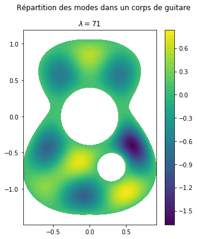

```python
widget_final = widgets.VBox(children=[tab, button])
widget_final
```

# Conclusion

Les simulations réalisées ont permis de visualiser les modes dans la guitare mais celles-ci peuvent facilement être étendues à d'autres instruments en trouvant l'équation du domaine correspondant. L'apport des fluctuations aléatoires a été très intéressant car il a permis de montrer comment la répartition dans le plan des modes était sensible aux paramètres. Cela soulève notamment des questions sur la précision minimale à apporter lors de la fabrication de l'instrument.

Pour rappel, chez un grand nombre d'instruments, la table d’harmonie mise en vibration grâce aux cordes est la source principale du son de l’instrument. La répartition spatiale des modes permet de caractériser entièrement le timbre d’un instrument. En d'autres termes, c’est ce phénomène qui fait que le son d’une guitare se distingue de celui d’un piano, même quand on y joue la même note. Ainsi, c'est sans grande surprise que de nombreux chercheurs se penchent sur l'utilisation des modes propres pour évaluer non plus **qualitativement** comme le font aujourd'hui la plupart des luthiers, mais **quantitativement** la qualité d'un instrument.

# Preuve supplémentaire quant à la validité de l'équation d'onde pour l'accoustique (optionnel, pour la curiosité du lecteur)

## Problème simplifié en 1D

Pour simplifier la modélisation, nous allons commencer par appréhender le problème en **1D**, c'est-à-dire dans le cas de la **corde vibrante** ou encore dite **corde de Melde**.

**Système complet :**

- Corde de masse linéique $\mu$, initialement tendue horizontalement.

**Bilan des forces :**

- Force $\vec{F}$ constante exercée en un des bouts de la corde et permettant de la maintenir tendue.

**Hypothèses supplémentaires :**

- Corde inextensible.
- Effets de la pesanteur négligeables devant les forces en jeu.

**Schéma du problème de la corde de Melde :**

[figure not shown]

**Source :** https://www.lelivrescolaire.fr/page/6967708

On choisit d'étudier le système suivant : *{brin de corde situé entre $x$ et $x + dx$}*.

**Schéma du problème élémentaire :**

[figure not shown]

**Source :** http://ressources.unisciel.fr/sillages/physique/ondes_mecaniques/res/eq-alembert.pdf

L'application du *Principe Fondamental de la Dynamique* au brin de corde permet d'obtenir le résultat suivant : \begin{equation} \mu d x \frac{\partial^{2} y}{\partial t^{2}} \vec{u}_{y}=\vec{T}_{g}(x, t)+\vec{T}_{d}(x+d x, t)=-\vec{T}_{d}(x, t)+\vec{T}_{d}(x+d x, t) \end{equation}

Projetant successivement selon (Ox) et (Oy), on tire :

\begin{equation} \left\{ \begin{array}{l} 0=-T(x, t) \cos \alpha(x, t)+T(x+d x, t) \cos \alpha(x+d x, t) \\ \mu d x \frac{\partial^{2} y}{\partial t^{2}}=-T(x, t) \sin \alpha(x, t)+T(x+d x, t) \sin \alpha(x+d x, t) \end{array} \right. \end{equation}

On suppose dx pris assez petit de telle sorte que $\alpha \ll 1$.  
Ainsi, on a : \begin{equation} \left\{ \begin{array}{l} \cos (\alpha) \approx 1 \\ \sin (\alpha) \approx \alpha \end{array} \right. \end{equation}

Ainsi la 1ère équation du système précédent fournit : \begin{equation} T(x+d x)=T(x)=\text{cste} = F \\ \end{equation}

De même, la deuxième équation fournit, en utilisant ce qui vient d'être trouvé ci-dessus : \begin{equation} \mu d x \frac{\partial^{2} y}{\partial t^{2}}=-F \alpha(x, t)+F \alpha(x+d x, t)=F \frac{\partial \alpha}{\partial x} d x \end{equation}

Ensuite, graphiquement, on tire la relation suivante (cf schéma) : \begin{equation} \tan \alpha=\frac{\partial y}{\partial x} \approx \alpha \end{equation}

Enfin, on réinjecte et on tire : \begin{equation} \mu \frac{\partial^{2} y}{\partial t^{2}}=F \frac{\partial^{2} y}{\partial x^{2}} \end{equation}

En posant $c = \sqrt{\frac{F}{\mu}}$, on retrouve finalement la célèbre équation d'onde, dite de d'Alembert : \begin{equation} \frac{\partial^{2} y}{\partial x^{2}}-\frac{1}{c^{2}} \frac{\partial^{2} y}{\partial t^{2}}=0 \end{equation}

## Problème complet en 2D

Le domaine 2D est pris avec un système de coordonnées cartésiennes (x,y). Ainsi, y sera renommée z dans la suite. On admettra que le résultat s'étend à un problème en 2D en faisant apparaître le laplacien : \begin{equation} \Delta z - \frac{1}{c^{2}} \frac{\partial^{2} z}{\partial t^{2}}=0 \end{equation}

**Bilan :** Nous avons bien montré que l'amplitude de vibration accoustique vérifiait l'équation d'onde.

# Bibliographie

- **Modélisation et obtention de l'EDP :**
  - UNISCIEL, *Equation d’onde de d’Alembert (unidimensionnelle)*. Disponible sur : http://ressources.unisciel.fr/sillages/physique/ondes_mecaniques/res/eq-alembert.pdf. Consulté le 01/03/2020.
- **Vidéo de la réalisation expérimentale des figures de Chladni :**
  - BRUSSPUP, *"Amazing Resonance Experiment!"*. Disponible sur : https://www.youtube.com/watch?feature=player_embedded&v=wvJAgrUBF4w. Consulté le 01/03/2020.
- **Obtention de l'équation géométrique pour le corps de guitare** :
  - RICHARD MARK FRENCH, *Engineering the Guitar: Theory and Practice*, accoustique, 266 pages. ISBN : 0387743693, 9780387743691. Consultable sur : https://books.google.fr/books?id=VJNptIvqN68C&dq=guitar+body+shape+geometric+equation&hl=fr&source=gbs_navlinks_s
  - FENICSPROJECT. *10. Generate mesh*. Disponible sur : https://fenicsproject.org/olddocs/dolfin/1.3.0/python/demo/documented/mesh-generation/python/documentation.html. Consulté le 21/03/2020.
- **Utilisation dans l'industrie :**
  - Pour la Science, *L’holographie au secours des luthiers*. Disponible sur : https://www.pourlascience.fr/sd/physique/lholographie-au-secours-des-luthiers-14192.php. Consulté le 22/03/2020.

# Remerciements

Je tiens à remercier Alexandre RICHARD pour sa précieuse aide pendant la réalisation de mon projet.